# lab9

Zeyuan Fang

10/6/2021

upi:zfan253  
id:556588804

## Description of Data

The data source for this lab is from UCI Machine Learning Repository. We are going to use the QSAR biodegradation data set, the description of which can be found here: https://archive.ics.uci.edu/ml/datasets/QSAR+biodegradation

The data set has 41 predictors (molecular descriptors) and one response variable class, which has two levels: RB (ready biodegradable) and NRB (not ready biodegradable).

To perform the following tasks, make sure we have loaded the following libraries:

```r
library(tree)
library(randomForest)
library(gbm)
```

## Training and Test Data

#### Task1. Randomly divide the data set into two halves, and save them in two data frames named train and test.

```r
biodeg <- read.csv("biodeg.csv")
biodeg$class <- as.factor(biodeg$class)
n <- nrow(biodeg)
set.seed(769)
index <- sample(n,n/2)
test <- biodeg[index,]
train <- biodeg[-index,]
```

```r
str(train)
```

```
## 'data.frame':    528 obs. of  42 variables:
##  $ SpMaxL  : num  3.93 5 4.6 5.04 4.21 ...
##  $ JDze    : num  3.25 5.05 3.08 3.61 2.63 ...
##  $ nHM     : int  0 1 0 0 0 0 1 0 0 0 ...
##  $ F01NN   : int  0 0 0 0 0 0 0 0 0 0 ...
##  $ F04CN   : int  0 0 0 1 0 0 0 0 0 0 ...
##  $ NssssC  : int  0 0 0 0 0 0 0 0 0 0 ...
##  $ nCb     : int  0 0 2 2 0 0 0 0 0 0 ...
##  $ C       : num  26.7 11.1 44.4 41.2 30 30 31.6 23.1 27.8 30 ...
##  $ nCp     : int  2 0 2 0 3 2 2 0 2 1 ...
##  $ nO      : int  4 3 0 4 0 0 0 0 1 1 ...
##  $ F03CN   : int  0 0 0 3 0 0 0 0 0 0 ...
##  $ SdssC   : num  0 0 0 -1.29 0 0 0 0 0 0 ...
##  $ HyWiBm  : num  3.28 2.87 2.97 3.48 2.52 ...
##  $ LOC     : num  2.585 0.722 0.875 1.258 1.459 ...
```

[output cut: 28 more lines]

```r
#str(test)
```

## Classification trees

#### Task2. Fit an unpruned classification tree to the training data. Plot it (as pretty as you can). Identify three most important variables from this classification tree.

```r
(r = tree(class ~ . , data=train))  # Unpruned tree
```

```
## node), split, n, deviance, yval, (yprob)
##       * denotes terminal node
##
##   1) root 528 685.200 NRB ( 0.64773 0.35227 )
##     2) SpMaxBm < 3.6815 242 321.400 RB ( 0.38017 0.61983 )
##       4) NssssC < 0.5 214 266.000 RB ( 0.31308 0.68692 )
##         8) nO < 0.5 66  89.300 NRB ( 0.59091 0.40909 )
##          16) F02CN < 2.5 49  67.740 RB ( 0.46939 0.53061 )
##            32) SpMaxBm < 3.0005 11   6.702 RB ( 0.09091 0.90909 ) *
##            33) SpMaxBm > 3.0005 38  51.730 NRB ( 0.57895 0.42105 ) *
##          17) F02CN > 2.5 17   7.606 NRB ( 0.94118 0.05882 ) *
##         9) nO > 0.5 148 143.600 RB ( 0.18919 0.81081 )
##          18) nN < 0.5 112  80.420 RB ( 0.11607 0.88393 )
##            36) PsiiA < 2.5585 65  65.050 RB ( 0.20000 0.80000 )
##              72) SdO < 10.623 45  54.100 RB ( 0.28889 0.71111 )
##               144) SM6Bm < 8.2825 37  32.800 RB ( 0.16216 0.83784 ) *
##               145) SM6Bm > 8.2825 8   6.028 NRB ( 0.87500 0.12500 ) *
##              73) SdO > 10.623 20   0.000 RB ( 0.00000 1.00000 ) *
##            37) PsiiA > 2.5585 47   0.000 RB ( 0.00000 1.00000 ) *
##          19) nN > 0.5 36  48.900 RB ( 0.41667 0.58333 )
##            38) C < 40.35 30  41.590 RB ( 0.50000 0.50000 )
##              76) Mi < 1.1445 7   0.000 NRB ( 1.00000 0.00000 ) *
##              77) Mi > 1.1445 23  29.720 RB ( 0.34783 0.65217 )
##               154) SpPosABp < 1.165 16  22.180 RB ( 0.50000 0.50000 ) *
##               155) SpPosABp > 1.165 7   0.000 RB ( 0.00000 1.00000 ) *
##            39) C > 40.35 6   0.000 RB ( 0.00000 1.00000 ) *
##       5) NssssC > 0.5 28  19.070 NRB ( 0.89286 0.10714 ) *
##     3) SpMaxBm > 3.6815 286 216.500 NRB ( 0.87413 0.12587 )
##       6) SpPosABp < 1.224 60  78.860 NRB ( 0.63333 0.36667 )
##        12) Mi < 1.1385 28  36.500 RB ( 0.35714 0.64286 )
##          24) nCp < 0.5 17  23.030 NRB ( 0.58824 0.41176 ) *
##          25) nCp > 0.5 11   0.000 RB ( 0.00000 1.00000 ) *
##        13) Mi > 1.1385 32  24.110 NRB ( 0.87500 0.12500 )
##          26) SpMaxA < 2.1575 7   9.561 RB ( 0.42857 0.57143 ) *
##          27) SpMaxA > 2.1575 25   0.000 NRB ( 1.00000 0.00000 ) *
##       7) SpPosABp > 1.224 226 105.000 NRB ( 0.93805 0.06195 )
##        14) SM6Bm < 8.382 17  22.070 NRB ( 0.64706 0.35294 )
##          28) HyWiBm < 3.0935 8   0.000 NRB ( 1.00000 0.00000 ) *
##          29) HyWiBm > 3.0935 9  11.460 RB ( 0.33333 0.66667 ) *
##        15) SM6Bm > 8.382 209  67.900 NRB ( 0.96172 0.03828 )
##          30) C026 < 1.5 110  57.340 NRB ( 0.92727 0.07273 )
##            60) F03CO < 9.5 103  40.010 NRB ( 0.95146 0.04854 ) *
##            61) F03CO > 9.5 7   9.561 NRB ( 0.57143 0.42857 ) *
##          31) C026 > 1.5 99   0.000 NRB ( 1.00000 0.00000 ) *
```

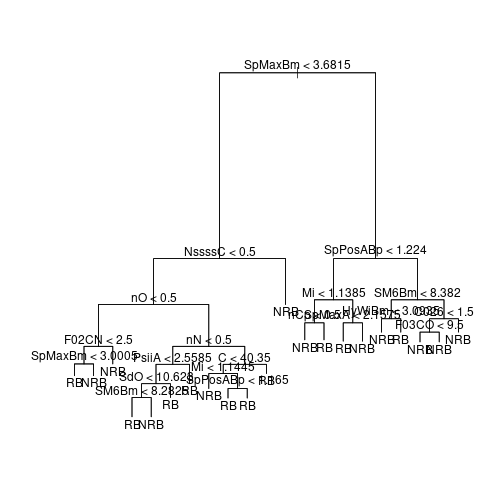

```r
plot(r)
text(r, pretty=0)
```

SpMaxBm, NssssC, SpPosABp are the three most important variables from this classification tree.

#### Task3. Compute the training and test errors.

Since we are going to compute the training and test errors frequently below, write a simple R function named errors() that computes both training and test errors and can be re-used for any family of models, as long as there is a function to supply the class labels. For example, running the function here may look like:

```r
errors(fit, fhat.tree, train, test)
```

where fit is the output of tree() and fhat.tree is a function that uses fit and computes the class labels for a data set (an argument of fhat.tree).

Demonstrate that errors() and fhat.tree() works correctly for the unpruned tree.

```r
fhat.tree<- function(fit,dataset){
  if(length(grep("gbm",fit$call))!=0)
    p <- predict(fit,dataset,type='response')
  else
    p <- predict(fit,dataset)
  if(class(p)=="matrix"){
    yhat = levels(biodeg$class)[apply(p, 1, which.max)]
    yhat
  }
  else if(class(p)== "factor"){
    p
  }
  else if(class(p)=="numeric"){
    yhat =levels(dataset$class)[(p > 0.5) + 1]
  }
  else{
    warning("Prediction output is not expected ")
  }
}
errors <- function(fit,fhat.tree,train,test){
  yhat_train <- fhat.tree(fit,train)
  yhat_test <- fhat.tree(fit,test)
  errs <- c(train_error= mean(train$class!=yhat_train),test_error=mean(test$class!=yhat_test))
  errs
}
errors(r,fhat.tree,train,test)
```

```
## train_error  test_error
##   0.1079545   0.2163188
```

#### Task4. Consider pruning the tree using cross-validation with deviance. Produce a pruned tree based by selecting a cost-complexity parameter value, and plot it. Compute the training and test errors for this pruned tree. Do you think the pruning helps?

```r
set.seed(769)
(cv.r = cv.tree(r))
```

```
## $size
##  [1] 21 20 19 18 16 15 14 12 11 10  9  7  6  5  4  3  2  1
##
## $dev
##  [1] 706.7849 672.4681 672.4681 595.6882 605.0534 584.1701 584.1701 569.0584
##  [9] 572.3426 577.8278 572.1718 572.4965 571.5285 538.3165 585.5325 585.4604
## [17] 592.0973 690.7302
##
## $k
##  [1]       -Inf   7.539453   7.773282   9.314800   9.590876  10.555918
##  [7]  10.617189  13.112194  13.463558  13.950377  14.552577  14.809566
## [13]  15.025110  18.247274  32.628928  33.146954  36.356443 147.247702
##
## $method
## [1] "deviance"
##
## attr(,"class")
## [1] "prune"         "tree.sequence"
```

```r
j.min = which.min(cv.r$dev)
k = cv.r$k[j.min]
r2 = prune.tree(r, k=k)
```

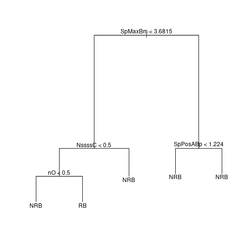

```r
plot(r2)
text(r2, pretty=0)
```

```r
errors(r2,fhat.tree,train,test)
```

```
## train_error  test_error
##   0.1780303   0.2125237
```

Although the test error only decreased a little, we get a much simpler tree, so the pruned tree does help here.

#### Taks5. Consider pruning the tree using cross-validation with misclassification rates. Produce a pruned tree by selecting a tree size, and plot it. Compute the training and test errors for this pruned tree. Do you think the pruning helps?

```r
set.seed(769)
(cv.r = cv.tree(r, method="misclass"))    # use misclassification rate
```

```
## $size
##  [1] 21 18 17 15 12  9  8  6  4  3  2  1
##
## $dev
##  [1] 112 106 101 102 105 105 109 117 119 122 143 188
##
## $k
##  [1]      -Inf  0.000000  1.000000  1.500000  2.000000  2.333333  3.000000
##  [8]  4.000000  4.500000 12.000000 22.000000 58.000000
##
## $method
## [1] "misclass"
##
## attr(,"class")
## [1] "prune"         "tree.sequence"
```

```r
# $dev are the numbers of misclassified observations
j.min = max(which(cv.r$dev == min(cv.r$dev)))     # if more than one, usually choose the simplest model
k = cv.r$k[j.min]
(r3 = prune.tree(r, k=k, method="misclass"))
```

```
## node), split, n, deviance, yval, (yprob)
##       * denotes terminal node
##
##   1) root 528 685.200 NRB ( 0.64773 0.35227 )
##     2) SpMaxBm < 3.6815 242 321.400 RB ( 0.38017 0.61983 )
##       4) NssssC < 0.5 214 266.000 RB ( 0.31308 0.68692 )
##         8) nO < 0.5 66  89.300 NRB ( 0.59091 0.40909 )
##          16) F02CN < 2.5 49  67.740 RB ( 0.46939 0.53061 )
##            32) SpMaxBm < 3.0005 11   6.702 RB ( 0.09091 0.90909 ) *
##            33) SpMaxBm > 3.0005 38  51.730 NRB ( 0.57895 0.42105 ) *
##          17) F02CN > 2.5 17   7.606 NRB ( 0.94118 0.05882 ) *
##         9) nO > 0.5 148 143.600 RB ( 0.18919 0.81081 )
##          18) nN < 0.5 112  80.420 RB ( 0.11607 0.88393 )
##            36) PsiiA < 2.5585 65  65.050 RB ( 0.20000 0.80000 )
##              72) SdO < 10.623 45  54.100 RB ( 0.28889 0.71111 )
##               144) SM6Bm < 8.2825 37  32.800 RB ( 0.16216 0.83784 ) *
##               145) SM6Bm > 8.2825 8   6.028 NRB ( 0.87500 0.12500 ) *
##              73) SdO > 10.623 20   0.000 RB ( 0.00000 1.00000 ) *
##            37) PsiiA > 2.5585 47   0.000 RB ( 0.00000 1.00000 ) *
##          19) nN > 0.5 36  48.900 RB ( 0.41667 0.58333 )
##            38) C < 40.35 30  41.590 RB ( 0.50000 0.50000 )
##              76) Mi < 1.1445 7   0.000 NRB ( 1.00000 0.00000 ) *
##              77) Mi > 1.1445 23  29.720 RB ( 0.34783 0.65217 ) *
##            39) C > 40.35 6   0.000 RB ( 0.00000 1.00000 ) *
##       5) NssssC > 0.5 28  19.070 NRB ( 0.89286 0.10714 ) *
##     3) SpMaxBm > 3.6815 286 216.500 NRB ( 0.87413 0.12587 )
##       6) SpPosABp < 1.224 60  78.860 NRB ( 0.63333 0.36667 )
##        12) Mi < 1.1385 28  36.500 RB ( 0.35714 0.64286 )
##          24) nCp < 0.5 17  23.030 NRB ( 0.58824 0.41176 ) *
##          25) nCp > 0.5 11   0.000 RB ( 0.00000 1.00000 ) *
##        13) Mi > 1.1385 32  24.110 NRB ( 0.87500 0.12500 ) *
##       7) SpPosABp > 1.224 226 105.000 NRB ( 0.93805 0.06195 )
##        14) SM6Bm < 8.382 17  22.070 NRB ( 0.64706 0.35294 )
##          28) HyWiBm < 3.0935 8   0.000 NRB ( 1.00000 0.00000 ) *
##          29) HyWiBm > 3.0935 9  11.460 RB ( 0.33333 0.66667 ) *
##        15) SM6Bm > 8.382 209  67.900 NRB ( 0.96172 0.03828 ) *
```

[figure not shown]

```r
plot(r2)
text(r2, pretty=0)
```

```r
errors(r3,fhat.tree,train,test)
```

```
## train_error  test_error
##   0.1098485   0.2277040
```

The pruned tree increase test error, hence it does not help here.

## Bagging

#### Task6. Produce a Bagging model for the training data with 500 trees construnted. What are the three most important variables, in terms of decreasing the Gini index, according to Bagging?

```r
set.seed(769)
p <- ncol(biodeg)-1
(r = randomForest(class ~ ., data=train,mtry=p, importance=TRUE))
```

```
##
## Call:
##  randomForest(formula = class ~ ., data = train, mtry = p, importance = TRUE)
##                Type of random forest: classification
##                      Number of trees: 500
## No. of variables tried at each split: 41
##
##         OOB estimate of  error rate: 14.96%
## Confusion matrix:
##     NRB  RB class.error
## NRB 310  32  0.09356725
## RB   47 139  0.25268817
```

```r
impt <-round(importance(r), 2)
impt[order(-impt[,4]),]
```

```
##            NRB    RB MeanDecreaseAccuracy MeanDecreaseGini
## SpMaxBm  29.81 30.04                45.78            69.74
## SpMaxL   11.49 17.45                20.15            14.62
## SM6Bm    23.33  8.90                24.43            12.90
## PsiiA    11.98  7.35                13.95             9.75
## SpPosABp 11.41  8.57                14.59             8.82
## nN       10.82 14.87                16.71             7.80
## Mi        9.11  8.82                13.32             7.76
## SdssC     5.92 11.76                11.84             7.46
## F02CN     5.55 17.70                17.44             7.28
## JDze      5.10  8.80                10.38             6.97
## HyWiBm   18.27  4.61                19.16             6.56
## NssssC   13.15 14.69                15.58             6.46
## C         1.84  9.30                 8.24             6.33
## nO        9.61  9.45                13.63             6.04
## nCp       9.52 11.92                13.91             6.00
## LOC       6.69  8.63                11.20             5.88
## nArCOOR   6.63 15.16                14.52             5.22
## TI2L      4.87  7.00                 8.74             5.21
## F03CO    10.83  6.56                12.54             5.08
## Me        5.01  4.51                 7.30             4.96
## SpMaxA    6.64  9.07                13.00             4.89
## Psii1d   10.19 -4.57                 7.17             4.63
## SM6L      8.68  3.38                10.22             3.98
## SdO       6.18  5.10                 8.26             2.76
## F04CN     0.35  9.72                 9.08             2.53
## F03CN     2.35  7.22                 6.98             2.07
## nHDon     3.69  2.56                 4.81             1.85
## nCrt      4.56  5.27                 7.10             1.57
## nCIR     -1.85  6.84                 6.97             1.14
## nHM      -3.95 10.76                 9.96             1.09
## nX       -2.26 10.32                 9.69             0.96
## nCb       1.09  4.65                 5.56             0.84
## C026      1.16  2.74                 2.84             0.60
## nNN       2.24  1.73                 2.85             0.28
## N073     -1.88 -1.74                -2.25             0.25
## B03CCl   -1.11  3.38                 2.82             0.24
## nArNO2    1.67  1.94                 2.78             0.14
## F01NN     1.40  2.47                 2.42             0.12
## B01CBr   -0.55  0.00                -0.57             0.03
## nCRX3     1.00  0.00                 1.00             0.01
## B04CBr    0.00  0.00                 0.00             0.00
```

SpMaxBm, SpMaxL, SM6Bm are the three most important variables, in terms of decreasing the Gini index.

#### Task7 Compute both the training and test errors of this Bagging predictor. Is your test error similar to the OOB estimate? Do you think Bagging helps prediction here?

```r
errors(r,fhat.tree,train,test)
```

```
## train_error  test_error
##   0.0000000   0.1271347
```

OOB error

```r
mean(r$err.rate[,1])
```

```
## [1] 0.1532442
```

The test error is smaller than OOB, which may implies that the test error is underestimated. However, no matter OOB error or test error show that Bagging really helps prediction here.

## Random Forests

#### Task8. Produce a Random Forest model with 500 trees constructed. What are the three most important variables, in terms of accuracy, according to Random Forest?

```r
set.seed(769)
p <- ncol(biodeg)-1
(r = randomForest(class ~ ., data=train,mtry=floor(sqrt(p)), importance=TRUE))
```

```
##
## Call:
##  randomForest(formula = class ~ ., data = train, mtry = floor(sqrt(p)),      importance = TRUE)
##                Type of random forest: classification
##                      Number of trees: 500
## No. of variables tried at each split: 6
##
##         OOB estimate of  error rate: 13.45%
## Confusion matrix:
##     NRB  RB class.error
## NRB 316  26  0.07602339
## RB   45 141  0.24193548
```

```r
impt <-round(importance(r), 2)
impt[order(-impt[,3]),]
```

```
##            NRB    RB MeanDecreaseAccuracy MeanDecreaseGini
## SpMaxBm  13.05 18.94                22.40            24.88
## SM6Bm    15.14 14.31                20.10            18.26
## SpMaxL   13.75 16.56                19.83            17.36
## SpPosABp 11.57 13.63                17.12            14.51
## HyWiBm   12.64 11.20                16.69            10.65
## SM6L     11.02 11.28                16.07            11.32
## SpMaxA   10.40 11.56                15.73            13.29
## nN       11.43 12.56                15.58             6.49
## F02CN     6.89 14.10                14.87             5.91
## nO        8.65 10.81                13.97             7.06
## PsiiA     9.36  8.74                13.07             7.45
## F03CO     8.33 10.07                12.89             6.40
## SdO       8.49 10.23                12.62             4.99
## nCp       7.88  9.93                12.10             4.90
## nHM       7.04 12.08                11.91             5.11
## NssssC    9.86  9.68                11.86             3.73
## JDze      7.85  7.61                11.68             7.87
## F03CN     5.74  9.93                11.53             3.90
## F04CN     6.29 10.16                11.32             3.45
## C         7.72  6.59                10.26             7.04
## TI2L      5.36  7.70                10.10             5.70
## nX        5.28  9.61                 9.97             2.69
## Mi        7.80  5.69                 9.80             8.09
## Me        8.40  3.79                 9.47             5.90
## LOC       5.82  6.55                 8.91             6.83
## SdssC     2.99  8.35                 7.97             5.26
## nCb       5.49  6.00                 7.76             4.20
## C026      5.65  4.86                 7.09             2.18
## nArCOOR   1.24  8.07                 6.81             1.98
## nCIR      2.95  6.50                 6.46             2.45
## Psii1d    6.78 -0.64                 5.68             4.51
## nHDon     3.51  4.04                 5.27             2.94
## F01NN     1.23  3.87                 3.45             0.42
## nCrt      2.21  1.76                 3.23             0.89
## nArNO2    1.94  2.34                 2.94             0.35
## nNN       2.74  2.10                 2.91             0.32
## B03CCl   -0.68  4.06                 2.63             0.67
## nCRX3     1.28  1.42                 1.76             0.04
## B01CBr   -0.55  1.55                 1.11             0.12
## B04CBr    1.00  0.00                 1.00             0.02
## N073      0.66  0.01                 0.66             0.19
```

SpMaxBm, SM6Bm, SpMaxL are the most important variable the three most important variables, in terms of accuracy, according to Random Forest.

#### Task9. Compute both the training and test errors of this Random Forest predictor. Is your test error similar to the OOB estimate? Do you think the tweak used by Random Forest helps prediction here?

```r
errors(r,fhat.tree,train,test)
```

```
## train_error  test_error
##   0.0000000   0.1404175
```

OOB error

```r
mean(r$err.rate[,1])
```

```
## [1] 0.140062
```

The test error is very close to OOB error. If we compare the OOB error between Bagging and Random Forest, since the OOB error of RF is smaller than that of Bagging, the tweak used by Random Forest helps prediction here.

## Boosting

#### task10. Produce a Boosting model, with 500 trees constructed.What are the three most important variables, according to Boosting?

```r
set.seed(769)
# use distribution="bernoulli" for a two-class classification problem
train2=cbind(train,class2=as.integer(train$class)-1)   # requires integer values
(r = gbm(class2 ~ . - class, data=train2, distribution="bernoulli", n.trees=500, interaction.depth=3))
```

```
## gbm(formula = class2 ~ . - class, distribution = "bernoulli",
##     data = train2, n.trees = 500, interaction.depth = 3)
## A gradient boosted model with bernoulli loss function.
## 500 iterations were performed.
## There were 41 predictors of which 36 had non-zero influence.
```

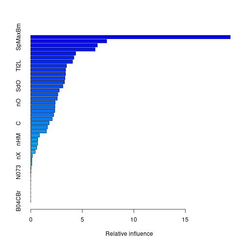

```
##               var      rel.inf
## SpMaxBm   SpMaxBm 19.364863710
## SpPosABp SpPosABp  7.369871684
## SM6Bm       SM6Bm  6.467359614
## SpMaxL     SpMaxL  6.249290037
## JDze         JDze  4.359556615
## PsiiA       PsiiA  4.188924618
## SpMaxA     SpMaxA  4.058583414
## TI2L         TI2L  3.478193385
## HyWiBm     HyWiBm  3.386601978
## nN             nN  3.374518683
## nCp           nCp  3.321499648
## SdssC       SdssC  3.277491666
## SdO           SdO  3.118523579
## F02CN       F02CN  2.772626886
## SM6L         SM6L  2.629741297
## LOC           LOC  2.578764253
## nO             nO  2.371496476
## F03CO       F03CO  2.351070915
## Psii1d     Psii1d  2.340443214
## Mi             Mi  2.225924587
## Me             Me  2.091198462
## C               C  1.786690538
## nHDon       nHDon  1.624784949
## F04CN       F04CN  1.522812025
## nCrt         nCrt  0.850231467
## nHM           nHM  0.688150304
## NssssC     NssssC  0.666360794
## C026         C026  0.587065521
## F03CN       F03CN  0.437460142
## nX             nX  0.164280641
## nCIR         nCIR  0.114023139
## nCb           nCb  0.110701067
## B03CCl     B03CCl  0.032182902
## N073         N073  0.024351261
## nArNO2     nArNO2  0.008563677
## nArCOOR   nArCOOR  0.005796850
## F01NN       F01NN  0.000000000
## nNN           nNN  0.000000000
## nCRX3       nCRX3  0.000000000
## B01CBr     B01CBr  0.000000000
## B04CBr     B04CBr  0.000000000
```

```r
summary(r)
```

SpMaxBm, SpPosABp, SM6Bm are the three most important variables, according to Boosting.

#### Task11. Compute both the training and test errors of this Boosting predictor.Do you think Boosting helps prediction here?

```r
errors(r,fhat.tree,train,test)
```

```
## Using 500 trees...
##
## Using 500 trees...
```

```
## train_error  test_error
##   0.0000000   0.1347249
```

Boosting helps prediction here since the test_error of Boosting is smaller than that of a single tree.

#### Task12. Demonstrate that Boosting can overfit.

```r
set.seed(769)
number_tree <- seq(10,1000,10)
errs <- data.frame(matrix(nrow=length(number_tree),ncol=2))
names(errs) <- c("training_error","test_error")
for(i in 1:length(number_tree)){
  (r = gbm(class2 ~ . - class, data=train2, distribution="bernoulli", n.trees=number_tree[i], interaction.depth=3))
  errs[i,]<- errors(r,fhat.tree,train,test)
}
```

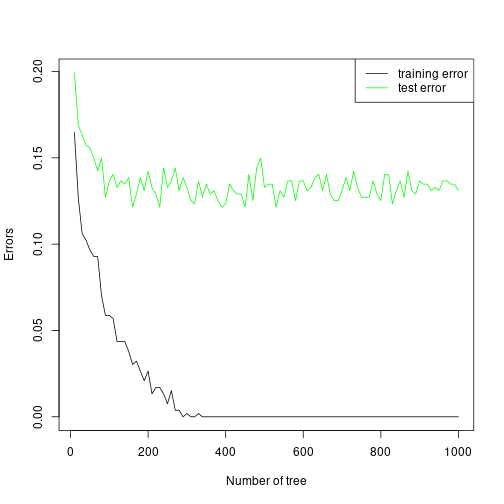

```r
plot(number_tree,errs$training_error,type='l',ylim=c(0,max(errs$test_error)),xlab="Number of tree",ylab="Errors")
lines(number_tree,errs$test_error,col='green')
legend("topright",legend=c("training error","test error"),lty=1,col=c("black","green"))
```